# Quantiles & Miscelaneous

We will learn this topic by using data of cholesterol levels for people that have smoked for at least 25 years.

Let’s do a histogram of our graph to see how the data looks.

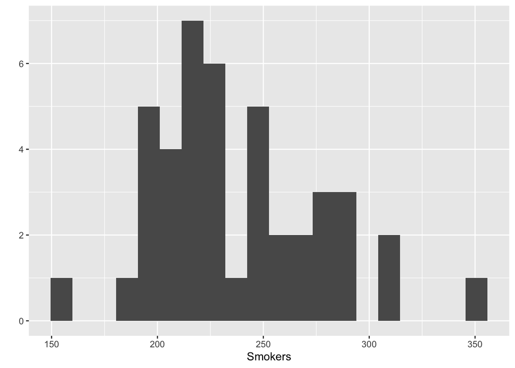

```r
# Vector smokers contains levels of colesterol
Smokers<-c(225, 211, 209, 284, 258, 216, 196, 288, 250, 200, 209, 280, 225, 256, 243, 200, 213, 246, 225, 237, 232, 267, 232, 216, 216, 243, 200, 155, 216, 271, NA, 230, 309, 183, 280, 217, 305, 287, 217, 246, 351, NA , 200, 280, 209)

# Try this code removing the knirt option warning=FALSE first, and remove the bins
qplot(Smokers, geom="histogram", bins=20)
```

# Frequency and proportion table

Frequency and porportion tables are useful tools to explore your data.

- Frequency table gives you the frequency of apearance of each value in a vector. To create one use function`table()`
- Proportion table provides the proportion that each value represents in the sample. To create one use function`prop.table(table())`

```r
#Frequency table
t<-table(Smokers)

#Proportion table
#prop.table(table())
p<-prop.table(table(Smokers))

#Use kable to make a nice looking table, here we use only the first 10 observations of the table.
kable(head(p,10), digits=3, col.names = c("Colesterol", "%"))
```

| Colesterol | % |
| --- | --- |
| 155 | 0.023 |
| 183 | 0.023 |
| 196 | 0.023 |
| 200 | 0.093 |
| 209 | 0.070 |
| 211 | 0.023 |
| 213 | 0.023 |
| 216 | 0.093 |
| 217 | 0.047 |
| 225 | 0.070 |

- A table that has both frequency and proportion is also a useful tool. Use the function `tabyl()` from the package janitor.

```r
pt<-tabyl(Smokers, sort = TRUE)
# Use kable but select only the relevant columns, only the first 10 observations of the table
kable(tabyl(Smokers, sort = TRUE)[1:10,c(1,2,4)], digits=3, col.names = c("Colesterol", "Frequency","%"))
```

| Colesterol | Frequency | % |
| --- | --- | --- |
| 155 | 1 | 0.023 |
| 183 | 1 | 0.023 |
| 196 | 1 | 0.023 |
| 200 | 4 | 0.093 |
| 209 | 3 | 0.070 |
| 211 | 1 | 0.023 |
| 213 | 1 | 0.023 |
| 216 | 4 | 0.093 |
| 217 | 2 | 0.047 |
| 225 | 3 | 0.070 |

# Quantiles

The quantiles divide the data into equal proportions, usually into quarters called quartiles, tenths called deciles, and percentages called percentiles. The default calculation in R is quartiles.

The function `quantile(x, probs = seq(0, 1, 0.25), na.rm = FALSE, names = TRUE, type = 7, ...)`

```r
#Calculate the quartiles of the data (remember this is the default option)
quantile(Smokers, na.rm=TRUE)
```

```
##    0%   25%   50%   75%  100%
## 155.0 212.0 230.0 262.5 351.0
```

```r
quantile(Smokers, 0.90, na.rm=TRUE) # gives you the 90 percentile for this data, this value means that 90% of the smokers had less than 287 in their cholesterol level.
```

```
##   90%
## 286.4
```

Sometimes it is also useful to have the quantiles in your data as part of the variables. The function `cut()` with `quantiles()` as the arguments to divide that data will do the trick.

Take a look at the new data.frame with the new quantile variable and make a graph of the average colesterol level for each quantile.

```r
# if you want to create a variable in your dataset that contains the quantiles
q<-cut(Smokers, quantile(Smokers, na.rm=TRUE), include.lowest=TRUE)
levels(q)<-c("25%","50%", "75%", "100%" )
# another way to do it is using the function quantcut
#q<-quantcut(Smokers, q=4, na.rm=TRUE)
q1<-as.integer(q)
q1<-q1*0.25
df<-data.frame(Smokers, q, q1)%>%na.omit()

# a table and a graph with the average colesterol level in each quartile

(tq<-df%>%group_by(q, q1)%>%summarise(AvgColesterol=mean(Smokers)))
```

```
## # A tibble: 4 x 3
## # Groups:   q [4]
##   q        q1 AvgColesterol
##   <fct> <dbl>         <dbl>
## 1 25%    0.25          197.
## 2 50%    0.5           220.
## 3 75%    0.75          244.
## 4 100%   1             291.
```

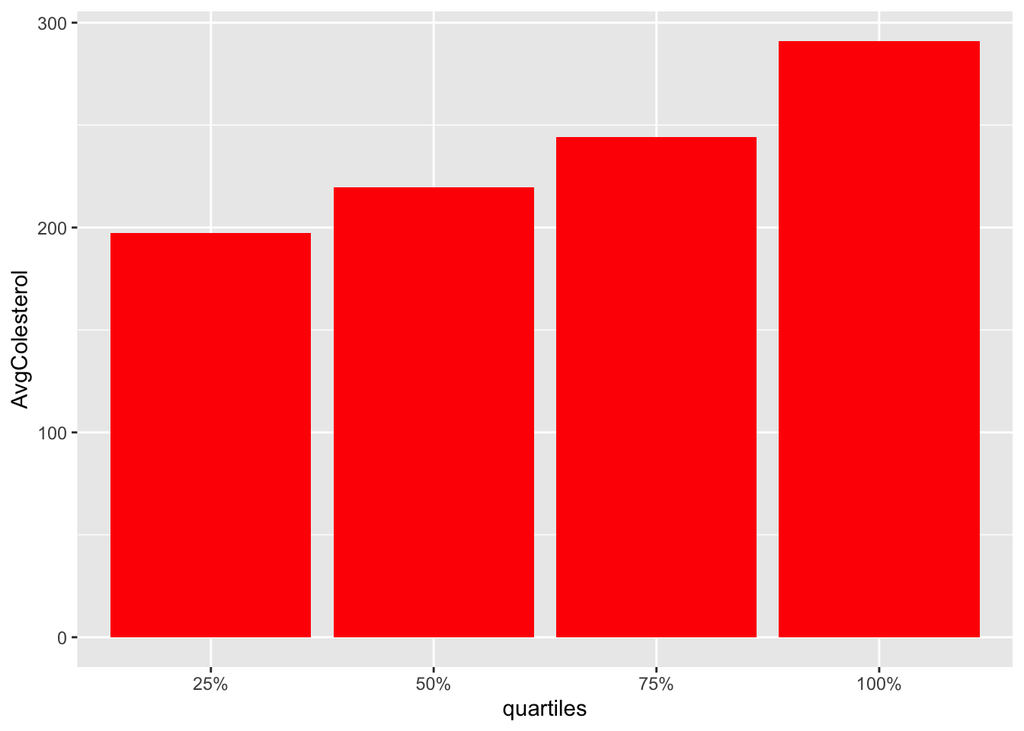

```r
tq%>%ggplot(aes(q, AvgColesterol))+geom_col(fill=2)+xlab("quartiles")
```

```r
(deciles<-seq(0,1, by=0.1)) # this creates a sequence from 0 to 1 by 0.1
```

```
##  [1] 0.0 0.1 0.2 0.3 0.4 0.5 0.6 0.7 0.8 0.9 1.0
```

- Use deciles to get the deciles in the smokers data using the function quantile

```r
quantile(Smokers, deciles, na.rm=TRUE)
```

```
##    0%   10%   20%   30%   40%   50%   60%   70%   80%   90%  100%
## 155.0 200.0 209.0 216.0 217.0 230.0 243.0 252.4 276.4 286.4 351.0
```

## Quantile function in the normal distribution. `qnorm()`

The quantile function in a distribution allows you to find the critical value associated with a certain probability. $\alpha=P(x>criticalvalue)$ `qnorm()` gives you that critical value

The table below shows the values asociated to different $alpha's$

```r
# The value of alpha is use for Hypothesis testing
alpha <- c(0.05, 0.01, 0.025)
# Critical values for given alpha using the normal approximation and the t-student with 1000 d.f:
n<-qnorm(alpha) # critical value for the normal distribution
n1<-round(qnorm(1-alpha), 3)
t<-round(qt(1-alpha, 1000), 3)

kable(data.frame(alpha, t , n, n1), digits=3, padding=5L, col.names = c("$\\alpha$", "T-student", "Normal-left","Normal-right"))
```

| $\alpha$ | T-student | Normal-left | Normal-right |
| --- | --- | --- | --- |
| 0.050 | 1.646 | -1.645 | 1.645 |
| 0.010 | 2.330 | -2.326 | 2.326 |
| 0.025 | 1.962 | -1.960 | 1.960 |

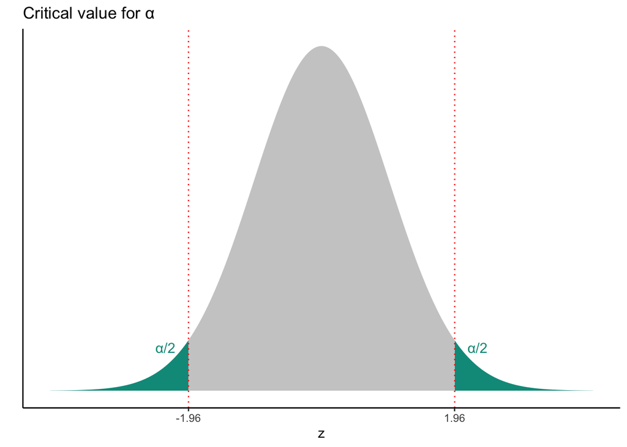